# wnba

From the plot below, the two bars are roughly the same height, so our dataset has almost the same number of wins and losses.

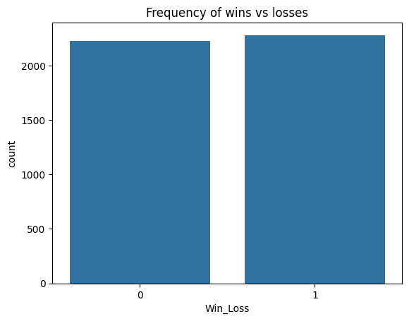

```python
import seaborn as sns
import matplotlib.pyplot as plt

sns.countplot(x = 'Win_Loss', data = df_cleaned)
plt.title("Frequency of wins vs losses")
plt.show()
```

The histogram is centered around 80-90 points per game. Most games, teams had scored in this range (80-90) with fewer very low and very high scoring games

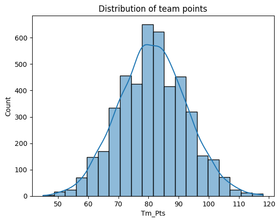

```python
sns.histplot(df_cleaned['Tm_Pts'],bins = 20, kde = True)
plt.title("Distribution of team points")
plt.show()
```

iii) Periodicity/Seasonality

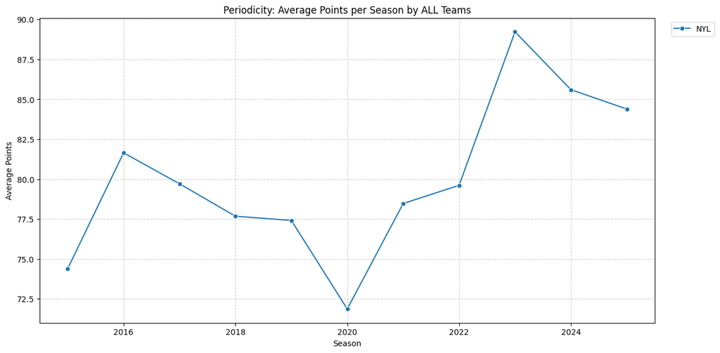

```python
avg_pts_all = df_cleaned.groupby(['Season','Team'])['Tm_Pts'].mean().reset_index()

nyl_data = avg_pts_all[avg_pts_all['Team'] == 'NYL']

plt.figure(figsize=(14, 7))

sns.lineplot(
    x='Season',
    y='Tm_Pts',
    hue='Team',
    data=nyl_data,
    palette='tab20',
    marker='o'
)

plt.title('Periodicity: Average Points per Season by ALL Teams')
plt.xlabel('Season')
plt.ylabel('Average Points')
plt.grid(True, linestyle='--', alpha=0.6)


plt.legend(bbox_to_anchor=(1.02, 1), loc='upper left')
plt.show()
```

The above graph shows the New York Liberty's average points per season over time. Scoring rises early (2015-2016), declines gradually through 2019, and drops sharply in 2020 (decrease in number of games played due to covid-19). From 2021 onward, NYL's offense rebounds strongly, peaking in 2023, then slightly declines but remains high. Overall, it shows long-term improvement with a major dip in 2020 and strong recent performance

Correlation between variables:

Tm_Pts and Tm_Off_rating are positively correlated (0.89) as teams that score more points tend to have higher offensive ratings. Tm_Asst and Tm_pts (0.61) are positively correlated as more assists is associated with higher scoring, overall better teamwork. Likewise, Tm_def_rating and Win_loss are negatively correlated (-0.56) as weak defense leads to losses.

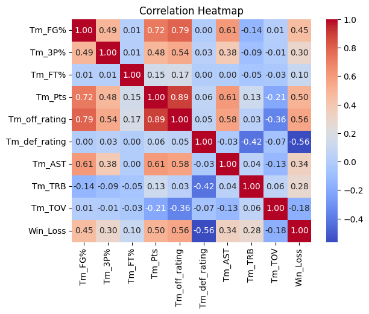

```python
corr = df_cleaned[['Tm_FG%', 'Tm_3P%', 'Tm_FT%', 'Tm_Pts', 'Tm_off_rating', 'Tm_def_rating', 'Tm_AST', 'Tm_TRB', 'Tm_TOV', 'Win_Loss']].corr()
sns.heatmap(corr, annot=True, fmt=".2f", cmap='coolwarm')
plt.title('Correlation Heatmap')
plt.show()
```

Pairwise relationship:

As field goal percentage increases, points scored also increases. Even from the correlation heatmap, we can infer that the value is 0.72 (positively correlated). Teams that shoot well and score more are far more likely to win.

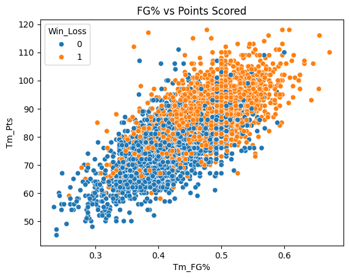

```python
sns.scatterplot(x='Tm_FG%', y='Tm_Pts', hue='Win_Loss', data=df_cleaned)
plt.title('FG% vs Points Scored')
plt.show()
```

'3 point' scored per-game from 2015-2025:

```python
df_3P = df_cleaned[['Season','Tm_3P']].copy()
df_3P = df_3P.groupby('Season',as_index = False).mean()
#df_3P = df_3P.sort_values('Season')
```

```python
df_3P
```

|  | Season | Tm_3P |
| --- | --- | --- |
| 0 | 2015 | 4.791176 |
| 1 | 2016 | 5.489305 |
| 2 | 2017 | 6.016043 |
| 3 | 2018 | 6.729064 |
| 4 | 2019 | 6.762255 |
| 5 | 2020 | 7.306818 |
| 6 | 2021 | 7.272251 |
| 7 | 2022 | 7.733796 |
| 8 | 2023 | 7.664583 |
| 9 | 2024 | 7.722917 |
| 10 | 2025 | 8.183566 |

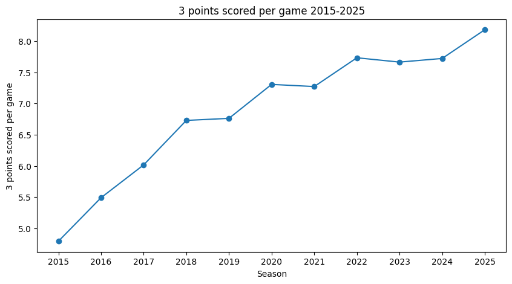

```python
import matplotlib.pyplot as plt
plt.figure(figsize = (10,5))
plt.plot(df_3P['Season'],df_3P['Tm_3P'],marker = 'o')
plt.title("3 points scored per game 2015-2025")
plt.xlabel("Season")
plt.ylabel("3 points scored per game")
plt.xticks(df_3P['Season'])
plt.show()
```

The chart shows a steady rise in three-pointers made per game from 2015-2025, increasing from under 5 to over 8 per game. Rapid growth in the earlier seasons reflect a strategic shift towards perimeter shooting, while slower increases and small fluctuations after 2019 suggest the three point shot has become a stable, core component of modern offensive play.

Simpson's Paradox: A team may have lower success rates in 2P%(2-point percentage) and 3P% (3 point percentage)but have a higher overall Field goal percentage (FG%).

In basketball, a common subgroup is 'shot type', specifically 2-point versus 3-point shots because teams attempt different proportions of these shots and 2-point shots are easier to make than 3-point shots.

I first calculated the number of 2-point shots mad and attempted for each game by subtracting the 3-point shots from the toal field goals and total field goal attempts. I aggregated these numbers across all games in a season for each team to obtrain the season totals for 2 point scored and attempts, 3-point scored and attempts. Using these totals, I calculated the season level shooting percentages for 2-pointers and 3-pointers and overall field-goals. So, the percentages are correctly weighted by the number of attempts.

By examining all pairs of teams, within each season to identify cases where Team A had lower 2P% and 3P% than Team B but a higher overall FG%. These pairs are examples of Simpson's paradox.

For example: SEA is better than MIN in both 2-point and 3-point shooting percentages. But the overall FG% for MIN is higher than SEA.

Reason: MIN may have scored easier 2-point shots which resulted in a high FG%. Even though, SEA was more accurate with the shot-type, they may have attempted more 3 pointers (difficult to score) which lowered their combined FG%

Reference: https://www.mickmel.com/simpsons-paradox-can-make-sports-stats-look-weird/

https://medium.com/@vplevris/simpsons-paradox-in-sports-when-better-every-season-still-means-worse-overall-c0508c2a96e6

```python
df_cleaned['Tm_2P'] = df_cleaned['Tm_FG'] - df_cleaned['Tm_3P']
df_cleaned['Tm_2PA'] = df_cleaned['Tm_FGA'] - df_cleaned['Tm_3PA']
```

```python
season_totals = df_cleaned.groupby(['Season', 'Team']).agg(
    Total_2P=('Tm_2P','sum'),
    Total_2PA=('Tm_2PA','sum'),
    Total_3P=('Tm_3P','sum'),
    Total_3PA=('Tm_3PA','sum')
).reset_index()
```

```python
season_totals['Tm_2P%'] = season_totals['Total_2P'] / season_totals['Total_2PA']
season_totals['Tm_3P%'] = season_totals['Total_3P'] / season_totals['Total_3PA']
season_totals['Tm_FG%'] = (season_totals['Total_2P'] + season_totals['Total_3P']) / \
                          (season_totals['Total_2PA'] + season_totals['Total_3PA'])
```

```python
print(season_totals[['Season','Team','Tm_2P%','Tm_3P%','Tm_FG%']].round(3))
```

```
     Season Team  Tm_2P%  Tm_3P%  Tm_FG%
0      2015  ATL   0.438   0.320   0.411
1      2015  CHI   0.472   0.327   0.446
2      2015  CON   0.454   0.335   0.422
3      2015  IND   0.443   0.360   0.424
4      2015  LAS   0.499   0.297   0.452
..      ...  ...     ...     ...     ...
124    2025  MIN   0.527   0.378   0.472
125    2025  NYL   0.522   0.355   0.453
126    2025  PHO   0.496   0.340   0.433
127    2025  SEA   0.501   0.342   0.450
128    2025  WAS   0.480   0.329   0.439

[129 rows x 5 columns]
```

```python
import itertools
def find_simpsons_paradox(season_totals):
    paradox_pairs = []

    for season in season_totals['Season'].unique():
        season_df = season_totals[season_totals['Season'] == season]


        for team_a, team_b in itertools.combinations(season_df['Team'], 2):
            a = season_df[season_df['Team'] == team_a].iloc[0]
            b = season_df[season_df['Team'] == team_b].iloc[0]


            if (a['Tm_2P%'] < b['Tm_2P%']) and (a['Tm_3P%'] < b['Tm_3P%']) and (a['Tm_FG%'] > b['Tm_FG%']):
                paradox_pairs.append({
                    'Season': season,
                    'Team A': team_a,
                    'Team B': team_b,
                    'Team A 2P%': a['Tm_2P%'],
                    'Team B 2P%': b['Tm_2P%'],
                    'Team A 3P%': a['Tm_3P%'],
                    'Team B 3P%': b['Tm_3P%'],
                    'Team A FG%': a['Tm_FG%'],
                    'Team B FG%': b['Tm_FG%']
                })

    return pd.DataFrame(paradox_pairs)


paradox_df = find_simpsons_paradox(season_totals)
print(paradox_df)
```

```
    Season Team A Team B  Team A 2P%  Team B 2P%  Team A 3P%  Team B 3P%  \
0     2016    MIN    SEA    0.499218    0.505472    0.337438    0.355167
1     2017    LAS    SEA    0.522145    0.523201    0.340866    0.362702
2     2018    LAS    WAS    0.489286    0.495581    0.346939    0.358344
3     2018    MIN    WAS    0.482112    0.495581    0.345936    0.358344
4     2020    CON    DAL    0.470324    0.473795    0.311005    0.322900
5     2020    LVA    SEA    0.498410    0.505387    0.367589    0.393617
6     2021    ATL    WAS    0.456079    0.463725    0.310127    0.328018
7     2021    IND    WAS    0.461350    0.463725    0.284420    0.328018
8     2022    CON    LVA    0.500000    0.519645    0.354391    0.360673
9     2022    DAL    NYL    0.480219    0.487926    0.343173    0.350754
10    2022    LAS    PHO    0.488605    0.496513    0.320197    0.328824
11    2022    LAS    SEA    0.488605    0.489717    0.320197    0.361171
12    2022    LAS    WAS    0.488605    0.490578    0.320197    0.337855
13    2024    DAL    PHO    0.489875    0.512134    0.325945    0.326004
```

[output cut: 22 more lines]

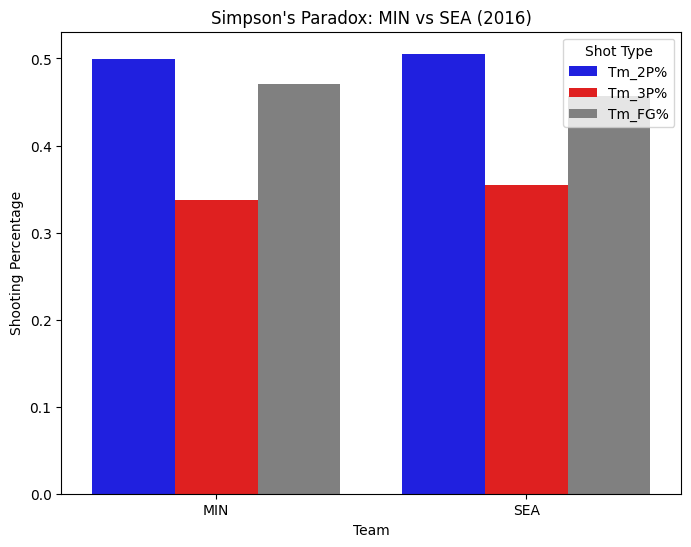

```python
if not paradox_df.empty:
    team_a = paradox_df.iloc[0]['Team A']
    team_b = paradox_df.iloc[0]['Team B']
    season = paradox_df.iloc[0]['Season']

    example = season_totals[(season_totals['Season'] == season) &
                            (season_totals['Team'].isin([team_a, team_b]))]


    example_melted = example.melt(id_vars=['Team'], value_vars=['Tm_2P%','Tm_3P%','Tm_FG%'],
                                  var_name='Shot Type', value_name='Percentage')

    plt.figure(figsize=(8,6))
    sns.barplot(x='Team', y='Percentage', hue='Shot Type', data=example_melted, palette=['blue','red','gray'])
    plt.title(f"Simpson's Paradox: {team_a} vs {team_b} ({season})")
    plt.ylabel('Shooting Percentage')
    plt.show()
```

7. Do you trust that this data is a reasonable dataset to use?

Yes. The variables in this dataset are clearly defined, I also verified that the calculated shooting percentages match the expected values based on scored and attempts. Each record represents a single team's performance metrics in a given game with information such as season, date and Home/away.

If needed, I can cross reference team statistics with basketball-reference (https://www.basketball-reference.com/), to validate any quesionable values.

8. Wrap up:

Through the data exploration process, I explored every variable in the dataset, including the variable's datatype, what it represents and the units it is measured in. I analyzed the relationship between several key performance metrics including Field Goal percentage (FG%), Offensive rating, points scored and their connection to team wins and losses. There was a strong positive correlation between FG% and Total points, teams that shoot efficiently tend to score more. One of the trends were winning teams generally had higher FG% and offensive ratings.

The data exploration supports my hypothesis, teams with higher FG% and 3P% tend to score more points and have a higher win rate. Some exceptions do exist, for example, a few teams with moderate shooting percentages still won games.

**Project-4:**

2. What kind of ML task is presented by your hypothesis and what type of learning it is?

My Hypothesis: Higher shooting efficiency (measured by field goal percentage or 3 Point percentage etc.) is associated with winning games.

The ML task presented in my hypothesis is a supervised classification problem as it aims to whether a team wins or loses a game based on in-game performance statistics(including shooting efficiency, rebounding). Historical WNBA game data will be used to train the model. Feature selection(RFECV, Wrapper method etc.) and dimensionality reduction (eg: PCA etc.) are planned to simplify the dataset and focus on the important features.

3. What features will you use?

Since the hypothesis primarily focuses on shooting efficiency, the features that are related to shooting efficiency will be chosen:

1. Field goal percentage
2. Three point percentage
3. Free-throw percentage

The columns: date, Team, Oppn, Season, Game number are redundant. So, they will be removed.

My goal is to identify which in-game performance statistics strongly influence whether a team wins a game.

A. Shooting Efficiency:

Tm_FG%, Tm_3P%, Tm_FT%, Tm_FG,Tm_FGA,Tm_3P,Tm_3PA, Tm_FT,Tm_FTA

B. Possesion and Turnover metrics:

Tm_TOV, Tm_tov_rate, Opp_tov_rate, Tm_poss

C. Rebounding:

Tm_ORB, Tm_TRB

D. Playmaking and Defense:

Tm_AST, Tm_STL, Tm_BLK

E. Opponent performance metrics:

Opp_FG%, Opp_3P%, Opp_FT%, Opp_TOV, Opp_TRB, Opp_AST

F. Engineered Features:

win_margin, Tm_off_rating, Tm_def_rating

Removed Columns:

Categorical Columns such as - Team, Season, Date, Game_Number, Opp, Home do not capture game performance. Raw scoring counts (Tm_pts, Opp_pts) are also dropped to focus on percentages and rates, which reflect better efficiency

Dimensionality reduction:

Principal Component Analysis:

The cleaned dataset initially had 27 features after removing identifiers and raw counts. Many of these features are highly correlated in basketball, in this context, this can lead to multicollinearity, where two or more independent variables have a high correlation with one another.

To address this, I used PCA to reduce multicollinearity and capture most of the dataset's variance with fewer dimensions. PCA transformed 27 features into 17 features while retaining 95% of the total variance. PCA helps the model to focus on the major patterns that contribute to winning

Features come from different statistical categories such as shooting percentages, rebounding counts, possession metrics and defensive statistics. These features exist on very different scales. StandardScaler is used which standardizes every feature to have a mean of 0 and standard deviation of 1. It uses z-score standardization.

https://scikit-learn.org/stable/modules/generated/sklearn.preprocessing.StandardScaler.html

```python
import pandas as pd
from sklearn.preprocessing import StandardScaler
from sklearn.decomposition import PCA

id_cols = ['Team', 'Season', 'Date', 'Game_Number', 'Opp', 'Home']
df = df_cleaned.copy()
df = df.drop(columns = id_cols, errors = 'ignore')

raw_shooting = ['Tm_FG', 'Tm_FGA','Tm_3P','Tm_3PA', 'Tm_FT','Tm_FTA',
                'Opp_FG', 'Opp_FGA', 'Opp_3P',
                'Opp_3PA', 'Opp_FT', 'Opp_FTA']



df = df.drop(columns = raw_shooting, errors = 'ignore')

df = df.drop(columns = ['Tm_Pts','Opp_Pts'], errors = 'ignore')

X = df.drop(columns = ['Win_Loss'])
y = df['Win_Loss']

X = X.fillna(X.mean())

scaler = StandardScaler()
X_scaled = scaler.fit_transform(X)

pca = PCA(n_components=0.95)
X_pca = pca.fit_transform(X_scaled)

explained_variance = pca.explained_variance_ratio_.cumsum()

for i,var in enumerate(explained_variance):
  print(f"Component {i+1}: {var:.4f}")
```

```
Component 1: 0.1486
Component 2: 0.2841
Component 3: 0.3946
Component 4: 0.4907
Component 5: 0.5737
Component 6: 0.6421
Component 7: 0.6940
Component 8: 0.7327
Component 9: 0.7697
Component 10: 0.8052
Component 11: 0.8384
Component 12: 0.8673
Component 13: 0.8933
Component 14: 0.9141
Component 15: 0.9347
Component 16: 0.9494
Component 17: 0.9630
```

Were you able to reduce the dimensionality of your dataset?

Yes. The dataset originally had 48 features. After removing non-performing columns, 27 features remained. PCA (95% variance) reduced 27 features down to 17 principal components which is 37% reduction.

What is the dimensionality of the resulting dataset you plan to use with your algorithm?

The dimensionality of the dataset before performing PCA is (4512,28)

The dimensionality of the resulting (after performing PCA) dataset is (4512,17).

```python
df.shape
```

```
(4512, 28)
```

```python
X_pca.shape
```

```
(4512, 17)
```

What assumptions can be reasonably made about the resulting dataset?

Since each row represents an independent team-game performance and there are no duplicate rows, independence between observations is a reasonable assumption. Standardizing the features ensures they are on the same scale, preventing any single variable from dominating the analysis.

```python
# Extra credit
X_ = df.drop(columns = ["Win_Loss"])
y = df_cleaned["Win_Loss"]

scaler = StandardScaler()
X_scaled = pd.DataFrame(scaler.fit_transform(X_), columns = X_.columns)
```

Extra Credit:

1. Filter based feature selection using ANOVA F-test:

The features are first standardized, then SelectKBest ranks them by how strongly they separate the target (Win_Loss). For each k value, the top k features with the highest F-statistics are selected

2. Wrapper method (Forward selection with KNN):

The wrapper method uses a KNN classifier to evaluate subsets of features. Starting from an empty set, features are added one by one to maximize the KNN model's performance

```python
# filter method

from sklearn.feature_selection import SelectKBest, f_classif

filter_results = {}

for k in [5,10,15]:
  selector = SelectKBest(score_func = f_classif, k=k)
  X_kbest = selector.fit_transform(X_scaled, y)
  filter_results[k] = X_kbest.shape[1]
filter_results

selector.get_support()

selected_features = X_scaled.columns[selector.get_support()]
selected_features
```

```
Index(['Tm_FG%', 'Tm_3P%', 'Tm_TRB', 'Tm_AST', 'Tm_STL', 'Tm_TOV', 'Opp_FG%',
       'Opp_3P%', 'Opp_TRB', 'Opp_AST', 'Opp_STL', 'win_margin',
       'Tm_off_rating', 'Tm_def_rating', 'Tm_tov_rate'],
      dtype='object')
```

```python
# wrapper method with forward selection

from mlxtend.feature_selection import SequentialFeatureSelector as SFS
from sklearn.neighbors import KNeighborsClassifier

knn = KNeighborsClassifier(n_neighbors = 5)
sfs_forward = SFS(knn,k_features = 15, forward = True,floating =True)
sfs_forward = sfs_forward.fit(X_scaled,y)

selected_features_forward = X_scaled.columns[list(sfs_forward.k_feature_idx_)]
selected_features_forward
```

```
Index(['Tm_FG%', 'Tm_3P%', 'Tm_AST', 'Tm_BLK', 'Tm_TOV', 'Opp_ORB', 'Opp_TRB',
       'Opp_STL', 'Opp_BLK', 'win_margin', 'Tm_poss', 'Opp_poss',
       'Tm_off_rating', 'Tm_def_rating', 'Tm_tov_rate'],
      dtype='object')
```

What are the names of the selected features, and for each one, are they discrete/categorical or continuous?

Names of the selected features from filter method:

Tm_FG% - continuous

Tm_3P% - continuous

Tm_AST - continuous

Tm_STL - continuous

Tm_TOV - continuous

Tm_TRB - continuous

Opp_FG% - continuous

Opp_TRB - continuous

Opp_3P% - continuous

Opp_AST- continuous

Opp_STL- continuous

win_margin - continuous

Tm_off_rating - continuous

Tm_def_rating - continuous

Tm_tov_rate - continuous

Two feature selection methods were applied to the dataset: a filter method (ANOVA F-test) and a wrapper method (forward selection using KNN). Both the methods reduced the features down to 15. The difference lies in which features were chosen:

The filter method selects features based on their individual statistical correlation with the target, ignoring interactions between the features. The wrapper method evaluates how subsets of features perform together in the model.

The benefit of reducing dimensionality is that it simplifies the dataset by keeping only the most important features. This makes models faster to train, reduces noise and errors and less likely to overfit.

4. What algorithm will you use?

For this project, a decision tree classifier will be used as a baseline model. A decision tree is appropriate because it can model non-linear relationships between in-game statistics and target outcomes.

What assumptions does this algorithm make?

Decision Trees do not assume that the features follow any specific distribution, they do not require features to be independent and they can handle moderate outliers.

In this dataset, many of the basketball statistics are correlated, eg: FGA relates to points and possesions, so using a model that is robust to correlation is better.

Decision Tree classifier help to model realtionships between shooting efficienty, turnovers, rebounding and defensive metrics.

Is this algorithm known to be prone to any issues that you should watch out for? Are there well-known mitigations you should use?

Limiting the depth of the tree prevents it from creating overly complex rules that apply only to a small subset of games. Similarly, requiring a minimum number of samples per leaf and split avoids divisions that are too specific to rare game outcomes.

Explain why you think this algorithm is a good candidate for the ML task

Decision Tree classifier is a good candidate for this task because it can capture non - linear relationships and handle interactions between features which are common in baskeball statistics. For example, a team's chance of winning depends not only on shooting efficiency but also on how turnovers, rebounds and assists interact in a game. A decision tree works by recursively splitting the data based on feature thresholds, forming regions where the target variable is more homogeneous. It is flexible with scaling and can be controlled with hyperparamers like max_depth and min_sample_leaf

5. What are the hyperparameters for your algorithm and how will you choose/tune them?

Hyperparameters for decision tree classifier:

1. max_depth = the maximum depth of the tree, how many layers of splits it can make.
2. min_samples_leaf = the minimum number of samples required to be in a leaf node
3. min_samples_split = the minimum number of samples needed for a node to be considered for a split
4. criterion = 'gini'. The function used to measure the quality of the split.
6. Are there any post processing techniques you may need to apply?

Decision trees can overfit if allowed to grow too deep, so post pruning is sometimes used to simplify a fully grown tree. In this project, the tree's complexity is controlled during training, by setting the pre-pruning hyperparameters (max_depth, min_samples_leaf, min_samples_split), the tree's complexity is controlled during training, so no additional post-processing is required.

```python
import pandas as pd
import numpy as np
from sklearn.model_selection import train_test_split
from sklearn.tree import DecisionTreeClassifier
from sklearn.metrics import accuracy_score
```

```python
X_train, X_test, y_train,y_test = train_test_split(X_pca,y,test_size = 0.2,random_state = 42)
```

```python
from sklearn.model_selection import GridSearchCV

param_grid = {'max_depth':[4,6,8,10],
              'min_samples_leaf':[1,5,10],
              'min_samples_split':[2,5,10]}

dt = DecisionTreeClassifier(criterion ='gini', random_state = 42)
grid = GridSearchCV(dt,param_grid,scoring = 'accuracy', cv =5)
grid.fit(X_train,y_train)

print("Best parameters:", grid.best_params_)
print("Best score:", grid.best_score_)
```

```
Best parameters: {'max_depth': 4, 'min_samples_leaf': 10, 'min_samples_split': 2}
Best score: 0.9600977405189006
```

Decision Tree classifier model is trained below:

```python
dt = DecisionTreeClassifier(max_depth =4, min_samples_leaf =10, min_samples_split =2, criterion ='gini', random_state = 42)
dt.fit(X_train,y_train)
```

```
DecisionTreeClassifier(max_depth=4, min_samples_leaf=10, random_state=42)
```

```python
y_pred = dt.predict(X_test)
```

accuracy score for pca

Training the model with filter method:

```python
# filter method with decision tree
X_selected = X_scaled[selected_features]

X_train_filter, X_test_filter, y_train_filter,y_test_filter = train_test_split(X_selected,y,test_size = 0.2,random_state = 42)

dt = DecisionTreeClassifier(max_depth =4, min_samples_leaf =10, min_samples_split =2, criterion ='gini', random_state = 42)
dt.fit(X_train_filter,y_train_filter)
```

```
DecisionTreeClassifier(max_depth=4, min_samples_leaf=10, random_state=42)
```

```python
y_pred_filter = dt.predict(X_test_filter)
```

accuracy for filter method:

```python
accuracy_score_filter = accuracy_score(y_test,y_pred_filter)
print("Accuracy:", accuracy_score_filter)
```

```
Accuracy: 1.0
```

```python
accuracy_score_pca = accuracy_score(y_test,y_pred)
print("Accuracy:", accuracy_score_pca)
```

```
Accuracy: 0.9545957918050941
```

```
Classification Report:
              precision    recall  f1-score     support
0              0.963719  0.944444  0.953984  450.000000
1              0.945887  0.964680  0.955191  453.000000
accuracy       0.954596  0.954596  0.954596    0.954596
macro avg      0.954803  0.954562  0.954588  903.000000
weighted avg   0.954774  0.954596  0.954590  903.000000

 Confusion Matrix (True vs Predicted)
[[425  25]
 [ 16 437]]
```

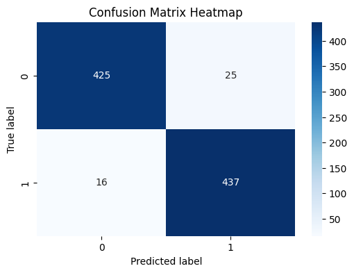

```python
report_dict = classification_report(y_test,y_pred,output_dict = True)
report_pca = pd.DataFrame(report_dict).transpose()

print("Classification Report:")
print(report_pca)

cm = confusion_matrix(y_test,y_pred)
print("\n Confusion Matrix (True vs Predicted)")
print(cm)

plt.figure(figsize=(6,4))
sns.heatmap(cm,annot=True,fmt='d',cmap='Blues')
plt.title('Confusion Matrix Heatmap')
plt.xlabel('Predicted label')
plt.ylabel('True label')
plt.show()
```

The decision tree on the selected features from filter method indicates overfitting. Applying PCA for dimensionality reduction has improved the decision tree's performance.

Although PCA features produced high accuracy (95.5%) and strong precision, recall and F1-scores, it combines original features into components.

**Project-5**

Previously, PCA, filter methods and a single decision tree classifier were applied for feature reduction and prediction. PCA was not suitable because it combines original features into abstract components, which makes it difficult to interpret the influence of game statistics.

The original dataset contained identifiers, redundant statistics, and outcome - derived variables. Includeing all features would introduce data leakage and reduced interpretability. Therefore, Identifiers such as Season, Team, Opponent, Date and Game Number were excluded because they do not describe in-game performance and may reduce generalizability. Outcome-related variables such as Team points, Opponent Points, Win Margin were removed to prevent data leakage, Raw box-score counts (field goals made and attempted) were exluded when corresponding efficiency metrics were available, as percentages better capture performance while reducing redundancy. Advanced metrics such as ratings, possessions and turnover rates were also excluded because they are computed from fundamental statistics already present in the dataset.

The final feature set consisted of 17 fundamental offensive and defensive statistics including shooting efficiency, rebounding, turnovers, fould, defensive actions for both teams.

Key Basketball performance features selected using domain knowledge are defined as the input variables, and the game outcome is defined as the target variable.

```python
from sklearn.model_selection import train_test_split
cols = ['Tm_FG%','Tm_3P%','Opp_FG%','Opp_3P','Tm_ORB','Tm_TRB','Tm_STL', 'Tm_BLK', 'Tm_TOV', 'Tm_PF','Opp_ORB', 'Opp_TRB', 'Opp_AST', 'Opp_STL', 'Opp_BLK', 'Opp_TOV',
       'Opp_PF']
X = df_cleaned[cols]
y = df_cleaned['Win_Loss']
```

All features are standardized to have zero mean and unit variance prior to model training and feature selection

```python
from sklearn.preprocessing import StandardScaler

X_train, X_test, y_train,y_test = train_test_split(X,y,test_size = 0.2,random_state = 42, stratify=y)


scaler = StandardScaler()
X_train_scaled = scaler.fit_transform(X_train)
X_test_scaled = scaler.transform(X_test)
```

RFECV (Recursive Feature Elimination with Cross-Validation) is a model-based feature selection technique that iteratively removes less important features while evaluating model performance using cross validation

```python
from sklearn.feature_selection import RFECV
from sklearn.linear_model import LogisticRegression
from sklearn.model_selection import StratifiedKFold
import matplotlib.pyplot as plt

estimator = LogisticRegression(solver='liblinear',random_state =42, max_iter=1000)

rfecv = RFECV(estimator = estimator, step = 1, cv = StratifiedKFold(5), scoring = 'accuracy')

rfecv.fit(X_train_scaled, y_train)

print(f"\n optimal number of features found by RFECV: {rfecv.n_features_}")



print("\n Optimal Feature Subset")
print(X.columns[rfecv.support_].tolist())
```

```
 optimal number of features found by RFECV: 17

 Optimal Feature Subset
['Tm_FG%', 'Tm_3P%', 'Opp_FG%', 'Opp_3P', 'Tm_ORB', 'Tm_TRB', 'Tm_STL', 'Tm_BLK', 'Tm_TOV', 'Tm_PF', 'Opp_ORB', 'Opp_TRB', 'Opp_AST', 'Opp_STL', 'Opp_BLK', 'Opp_TOV', 'Opp_PF']
```

RFECV was applied using logistic regression as the base model and accuracy as the scoring metric. Conceptually, RFECV removes the least important feature at each step and checks whether cross-validated performance improves. If removing a feature would reduce performance, it is retained.

In this case, all 17 features were retained because logistic regression uses feature coefficients to assess importance, and RFECV removes only features whose exclusion does not reduce cross-validated accuracy. All selected features contributed to maintaining optimal performance.

The dataset is reduced to the subset of features selected by RFECV. These features are then standardized again to ensure consistent scaling before training.

```python
optimal_cols = X.columns[rfecv.support_]
X_train_optimal = X_train[optimal_cols]
X_test_optimal = X_test[optimal_cols]

scaler = StandardScaler()
X_train_optimal_scaled = scaler.fit_transform(X_train_optimal)
X_test_optimal_scaled = scaler.transform(X_test_optimal)
```

Logistic Regression model:

Finally, a logistic regression model is trained on this proccessed training set. Logistic regression is used to predict game outcomes (Win/Loss) from the selected performance features. It models the probability of a win based on each feature and uses the learned coefficients to make predictions on new games.

```python
logreg_model = LogisticRegression(solver = 'liblinear',random_state = 42, max_iter = 1000)
logreg_model.fit(X_train_optimal_scaled,y_train)
```

```
LogisticRegression(max_iter=1000, random_state=42, solver='liblinear')
```

The code intializes a logistic regression model with the liblinear solver, which is well-suited for small to medium datasets. 'Max_iter = 1000' allows the solver to converge.

Logistic Regression training:

The code below evaluates the trained logistic regression model on the test set using multiple metrics such as: accuracy, f1- score, precision, recall, classification report and confusion matrix. A heatmap of the confusion matrix is also plotted for easy visualization

```
Train Accuracy: 0.941812136325852
Test Accuracy: 0.9424141749723145
Classification Report:
              precision    recall  f1-score     support
0              0.941704  0.941704  0.941704  446.000000
1              0.943107  0.943107  0.943107  457.000000
accuracy       0.942414  0.942414  0.942414    0.942414
macro avg      0.942406  0.942406  0.942406  903.000000
weighted avg   0.942414  0.942414  0.942414  903.000000

 Confusion Matrix (True vs Predicted)
[[420  26]
 [ 26 431]]
```

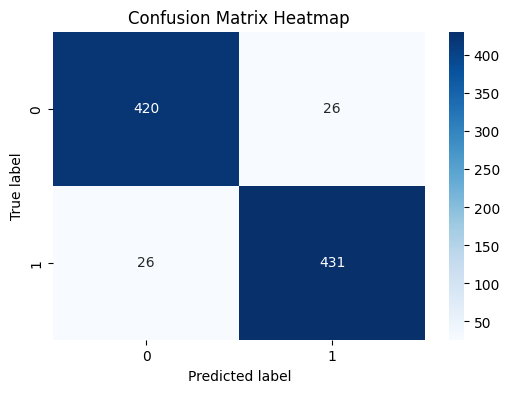

```python
from sklearn.metrics import accuracy_score, classification_report, confusion_matrix
import seaborn as sns


y_train_pred = logreg_model.predict(X_train_optimal_scaled)
train_accuracy = accuracy_score(y_train,y_train_pred)
print(f"Train Accuracy: {train_accuracy}")

y_pred_ = logreg_model.predict(X_test_optimal_scaled)
test_accuracy = accuracy_score(y_test,y_pred_)
print(f"Test Accuracy: {test_accuracy}")

report_dict = classification_report(y_test,y_pred_,output_dict = True)
report_lr = pd.DataFrame(report_dict).transpose()

print("Classification Report:")
print(report_lr)

cm = confusion_matrix(y_test,y_pred_)
print("\n Confusion Matrix (True vs Predicted)")
print(cm)

plt.figure(figsize=(6,4))
sns.heatmap(cm,annot=True,fmt='d',cmap='Blues')
plt.title('Confusion Matrix Heatmap')
plt.xlabel('Predicted label')
plt.ylabel('True label')
plt.show()
```

Metrics:

Accuracy: measures the overall proportion of games correctly predicted as wins or losses.

Precision: measures the proportion of predicted wins that were actual wins.

Recall: measures the proportion of actual wins correctly predicted.

F1-Score: combines precision and recall into a single measure and provides a balanced view of the model's ability to correctly identify wins.

Confusion Matrix: shows the counts of true positives (games that were actually wins and predicted as wins), true negatives (games that were losses and predicted as losses), false positives(games that were losses but predicted as wins) and false negatives(games that were wins but predicted as losses). This highlights whether the model is consistently predicting wins or losses correctly.

Inference from results:

The logistic regression model achieved train accuracy is 0.941 and test accuracy is 0.942. Precision and recall and F1-scores are all 0.94. The confusion matrix confirms few, evenly distributed misclassifications. These results support the hypothesis that the selected performance features effectively capture the factors influencing game outcomes.

L2-regularized logistic regression:

To address potential overfitting in original logistic overfitting, L2-regularized logistic regression is applied

L2 regularization is a technique that penalizes large coefficients in a model by adding the sum of their squares to the loss function. This shrinks the coefficients toward zero without removing any features, which helps the model avoid overfitting and generalize better to unseen data.

In the code below, RFECV with L2 regularized logistic regression selected 17 optimal features. L2 regulatization did not remove any features, showing that none are redundant or irrelevant in the presence of coefficient shrinkage

```python
from sklearn.feature_selection import RFECV
from sklearn.linear_model import LogisticRegression
from sklearn.model_selection import StratifiedKFold
import matplotlib.pyplot as plt

estimator_l2 = LogisticRegression(solver='liblinear',penalty = 'l2',random_state =42, max_iter=1000)

rfecv_l2= RFECV(estimator = estimator, step = 1, cv = StratifiedKFold(5), scoring = 'accuracy')

rfecv_l2.fit(X_train_scaled, y_train)

print(f"\n optimal number of features found by RFECV: {rfecv_l2.n_features_}")



print("\n Optimal Feature Subset")
print(X.columns[rfecv_l2.support_].tolist())
```

```
 optimal number of features found by RFECV: 17

 Optimal Feature Subset
['Tm_FG%', 'Tm_3P%', 'Opp_FG%', 'Opp_3P', 'Tm_ORB', 'Tm_TRB', 'Tm_STL', 'Tm_BLK', 'Tm_TOV', 'Tm_PF', 'Opp_ORB', 'Opp_TRB', 'Opp_AST', 'Opp_STL', 'Opp_BLK', 'Opp_TOV', 'Opp_PF']
```

```python
optimal_cols = X.columns[rfecv_l2.support_]
X_train_optimal_l2 = X_train[optimal_cols]
X_test_optimal_l2= X_test[optimal_cols]

scaler = StandardScaler()
X_train_optimal_scaled_l2 = scaler.fit_transform(X_train_optimal_l2)
X_test_optimal_scaled_l2 = scaler.transform(X_test_optimal_l2)
```

L2 regularized logistic regression training:

The code below trains and evaluates logistic regression model with l2 regularization on the selected and scaled features. The model is initialized with penalty = 'l2' to shrink coefficients and reduce overfitting.

```
Train Accuracy: 0.941812136325852
L2 Logistic Regression Test Accuracy: 0.9424141749723145

Classification Report:
              precision    recall  f1-score     support
0              0.941704  0.941704  0.941704  446.000000
1              0.943107  0.943107  0.943107  457.000000
accuracy       0.942414  0.942414  0.942414    0.942414
macro avg      0.942406  0.942406  0.942406  903.000000
weighted avg   0.942414  0.942414  0.942414  903.000000
```

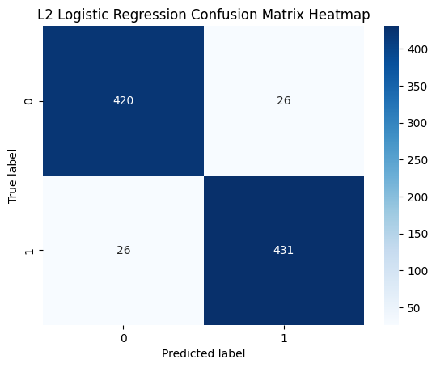

```python
# regularized logistic regression

logreg_l2 = LogisticRegression(solver = 'liblinear',penalty = 'l2',random_state = 42, max_iter = 1000)
logreg_l2.fit(X_train_optimal_scaled_l2,y_train)

y_train_pred_l2 = logreg_model.predict(X_train_optimal_scaled_l2)
train_accuracy_l2 = accuracy_score(y_train,y_train_pred_l2)
print(f"Train Accuracy: {train_accuracy_l2}")

y_pred_l2 = logreg_l2.predict(X_test_optimal_scaled_l2)

accuracy_l2 = accuracy_score(y_test,y_pred_l2)
print(f"L2 Logistic Regression Test Accuracy: {accuracy_l2}\n")
report_dict = classification_report(y_test,y_pred_l2,output_dict = True)
report_l2 = pd.DataFrame(report_dict).transpose()

print("Classification Report:")
print(report_l2)

cm_l2 = confusion_matrix(y_test,y_pred_l2)
sns.heatmap(cm_l2,annot=True,fmt='d',cmap='Blues')
plt.title('L2 Logistic Regression Confusion Matrix Heatmap')
plt.xlabel('Predicted label')
plt.ylabel('True label')
plt.show()
```

Inference from the result:

Decision Tree Classifier:

In the code below, RFECV is run using decision as the classifier

```python
from sklearn.feature_selection import RFECV
from sklearn.tree import DecisionTreeClassifier
from sklearn.model_selection import StratifiedKFold
import matplotlib.pyplot as plt

dt_estimator = DecisionTreeClassifier(random_state = 42,max_depth = 5)

rfecv_dt= RFECV(estimator = dt_estimator, step = 1, cv = StratifiedKFold(5), scoring = 'accuracy')

rfecv_dt.fit(X_train_scaled, y_train)

print(f"\n optimal number of features found by RFECV: {rfecv_dt.n_features_}")



print("\n Optimal Feature Subset")
print(X.columns[rfecv_dt.support_].tolist())
```

```
 optimal number of features found by RFECV: 6

 Optimal Feature Subset
['Tm_FG%', 'Tm_3P%', 'Opp_FG%', 'Tm_TOV', 'Opp_TRB', 'Opp_TOV']
```

RFECV selected 6 optimal features for the decision tree classifier.

```python
optimal_cols = X.columns[rfecv_dt.support_]
X_train_optimal_dt = X_train[optimal_cols]
X_test_optimal_dt= X_test[optimal_cols]

scaler = StandardScaler()
X_train_optimal_scaled_dt = scaler.fit_transform(X_train_optimal_dt)
X_test_optimal_scaled_dt = scaler.transform(X_test_optimal_dt)
```

The code below trains a decision tree classifier with a maximum depth of 5 on the RFECV-selected features and evaluates its performance on the test set.

```
Decision Tree Classifier Test Accuracy: 0.7995570321151716

Classification Report:
              precision    recall  f1-score     support
0              0.770961  0.845291  0.806417  446.000000
1              0.833333  0.754923  0.792193  457.000000
accuracy       0.799557  0.799557  0.799557    0.799557
macro avg      0.802147  0.800107  0.799305  903.000000
weighted avg   0.802527  0.799557  0.799218  903.000000
```

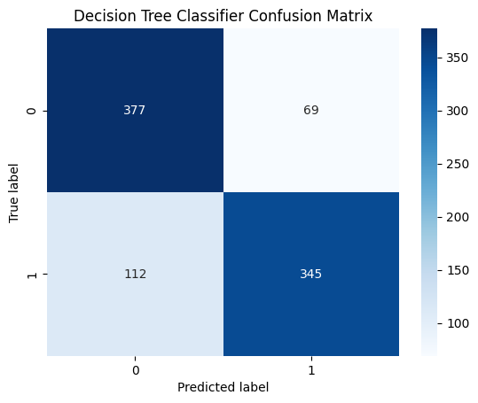

```python
# decision tree classifier
from sklearn.tree import DecisionTreeClassifier

dt_model = DecisionTreeClassifier(max_depth = 5, random_state = 42)
dt_model.fit(X_train_optimal_scaled_dt, y_train)

y_pred_dt = dt_model.predict(X_test_optimal_scaled_dt)

accuracy_dt = accuracy_score(y_test,y_pred_dt)
print(f"Decision Tree Classifier Test Accuracy: {accuracy_dt}\n")
report_dict = classification_report(y_test,y_pred_dt,output_dict = True)
report_dt = pd.DataFrame(report_dict).transpose()

print("Classification Report:")
print(report_dt)
cm_dt = confusion_matrix(y_test,y_pred_dt)
sns.heatmap(cm_dt,annot=True,fmt='d',cmap='Blues')
plt.title('Decision Tree Classifier Confusion Matrix')
plt.xlabel('Predicted label')
plt.ylabel('True label')
plt.show()
```

The decision tree has achieved a test accuracy of ~0.80 which is lower thatn logistic regression and l2-logistic regression models. It captures patterns but is less robust on unseen data. Precision and recall differ slightly between classes. The confusion matrix shows that some wins and losses are misclassified.

Random Forest Classifier:

The decision tree achieved moderate performance but with several misclassifications, so random forest classifier is implemented next.

Random forest is an ensemble learning method that builds multiple decision trees on random subsets of the data and features. Each tree makes a prediction, and the final output is determined by majority voting. This approach reduced overfitting compared and can capture complex, non linear relationships in the data

In the code below, RFECV is run using random forest as the classifier

```python
from sklearn.feature_selection import RFECV
from sklearn.ensemble import RandomForestClassifier
from sklearn.model_selection import StratifiedKFold
import matplotlib.pyplot as plt

rf_estimator = RandomForestClassifier(n_estimators = 100,random_state = 42,max_depth = 5)

rfecv_rf= RFECV(estimator = rf_estimator, step = 1, cv = StratifiedKFold(5), scoring = 'accuracy')

rfecv_rf.fit(X_train_scaled, y_train)

print(f"\n optimal number of features found by RFECV: {rfecv_rf.n_features_}")



print("\n Optimal Feature Subset")
print(X.columns[rfecv_rf.support_].tolist())
```

```
 optimal number of features found by RFECV: 15

 Optimal Feature Subset
['Tm_FG%', 'Tm_3P%', 'Opp_FG%', 'Opp_3P', 'Tm_ORB', 'Tm_TRB', 'Tm_STL', 'Tm_TOV', 'Tm_PF', 'Opp_ORB', 'Opp_TRB', 'Opp_AST', 'Opp_STL', 'Opp_TOV', 'Opp_PF']
```

RFECV selected 15 features as optimal for the random forest classifier. They include key team and opponent statistics that directly influence game outcome.

```python
optimal_cols = X.columns[rfecv_rf.support_]
X_train_optimal_rf = X_train[optimal_cols]
X_test_optimal_rf= X_test[optimal_cols]

scaler = StandardScaler()
X_train_optimal_scaled_rf = scaler.fit_transform(X_train_optimal_rf)
X_test_optimal_scaled_rf = scaler.transform(X_test_optimal_rf)
```

This code trains a random forest classifier on the selected features and evaluates its performance

```
Train Accuracy: 0.941812136325852
Random Forest Classifier Test Accuracy: 0.858250276854928

Classification Report:
              precision    recall  f1-score    support
0              0.854911  0.858744  0.856823  446.00000
1              0.861538  0.857768  0.859649  457.00000
accuracy       0.858250  0.858250  0.858250    0.85825
macro avg      0.858225  0.858256  0.858236  903.00000
weighted avg   0.858265  0.858250  0.858253  903.00000
```

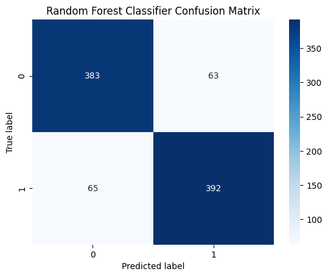

```python
# random forest classifier

from sklearn.ensemble import RandomForestClassifier

rf_model = RandomForestClassifier(n_estimators = 100, random_state = 42,max_depth = 5)
rf_model.fit(X_train_optimal_scaled_rf,y_train)

y_train_pred_l2 = logreg_model.predict(X_train_optimal_scaled_l2)
train_accuracy_l2 = accuracy_score(y_train,y_train_pred_l2)
print(f"Train Accuracy: {train_accuracy_l2}")

y_pred_rf = rf_model.predict(X_test_optimal_scaled_rf)

accuracy_rf = accuracy_score(y_test,y_pred_rf)
print(f"Random Forest Classifier Test Accuracy: {accuracy_rf}\n")
report_dict = classification_report(y_test,y_pred_rf,output_dict = True)
report_rf = pd.DataFrame(report_dict).transpose()

print("Classification Report:")
print(report_rf)

cm_rf = confusion_matrix(y_test,y_pred_rf)
sns.heatmap(cm_rf,annot=True,fmt='d',cmap='Blues')
plt.title('Random Forest Classifier Confusion Matrix')
plt.xlabel('Predicted label')
plt.ylabel('True label')
plt.show()
```

The selected features explain why the model performs well. Shooting efficiency (Tm_FG%,Tm_3P%) reflects how effectively a team converts scoring opportunities, while opponent shooting metrics (Opp_FG%, Opp_3P) capture defensive pressure. Rebounding statistics describe control over possessions, turnovers indicate ball security, and steals and fouls reflect defensive activity. Together, these features describe how games are actually decided, which helps the model distinguish wins from losses more reliably

**Insights:**

1. What did you find in terms of your hypothesis?

Hypothesis: Higher shooting efficiency (measured by field goal percentage or 3 Point percentage etc.) is associated with winning games.

Classification models (logistic regression, l2-regularized logistic regression, decision tree and random forest) show that features such as Tm_FG%, Tm_3P%, and defensive/possession metrics (Tm_TRB,Tm_TOV,Opp_TRB,Opp_TOV) are highly informative in distinguishing wins from losses. RFECV confirms that shooting efficiency and certain defensive metrics are the strongest predictors. This supports the hypothesis: games won are strongly associated with higher shooting efficiency and good defensive control.

2. Any previous assumptions that you had to adjust, or proved wrong?

Originally, only team shooting efficiency was assumed to matter. The analysis shows that opponent statistics and turnovers also significantly influence outcomes. Not all available features contribute equally; a subset of features capture most of the predictive power.

3. Is the problem different from what you had originally thought?

Initially, the focus was on offense. Results indicate that both offense and defense (defensive statistics such as rebounds, steals and turovers) are critical in determining game outcomes.

4. Anything you would do differently if you were to do it again?

I would analyze sequences of games to capture momentum or performance trends. Although, I have addressed '3 point scored per game' performance trend from 2015-2025, in the previous section, extending ML models to include temporal patterns could improve predictions.

5. Are there any policy or other decisions that could be influenced by an analysis like yours?

Coaches can focus on improving shooting efficiency, minimizing turnovers and strengthening defensive play. Teams can prioritize player selection and training based on metrics that truly influence game outcomes.

6. What ethical concerns should you or someone reading your project consider?

Predictive models should not be exploited for gambling, which raises legal and ethical concerns.

7. Final thoughts: Summarize your experience across all 5 projects. What did you learn?

Across the five projects, I learned the complete data science pipeline. Early on, I learned the importance of careful data cleaning and validation, especially recognizing that extreme values in basketball statistics often reflect real performances rather than errors and are worth cross-verifying rather than removing.

One of the biggest takeaways was realizing that winning is not driven by offense alone, defense stats like turnovers and opponent performance are just as important. What started as a simple question about whether shooting efficiency leads to winning in the WNBA evolved into an analysis of how offense, defense, and opponent behavior interact.